# Kerentanan Sosial Terhadap COVID-19 di DKI Jakarta Menggunakan Analisis Faktor dan Kluster

## Pendahuluan

### Latar Belakang

Setiap harinya, jumlah kasus positif COVID-19 di Indonesia terus mengalami peningkatan. Provinsi DKI Jakarta menjadi provinsi dengan jumlah kasus positif COVID-19 terbanyak di Indonesia. Meski disadari bahwa virus COVID-19 dapat menginfeksi siapa saja, tetapi beberapa kelompok orang memiliki tingkat risiko yang lebih tinggi untuk terpapar. Sebagai contoh, jika dilihat pada data kematian akibat COVID-19 per kelompok umur per tanggal 1 September 2022, penduduk rentan seperti usia lansia (≥ 60 tahun) menyumbang kematian sebesar 47,6% dari total kematian akibat COVID-19.

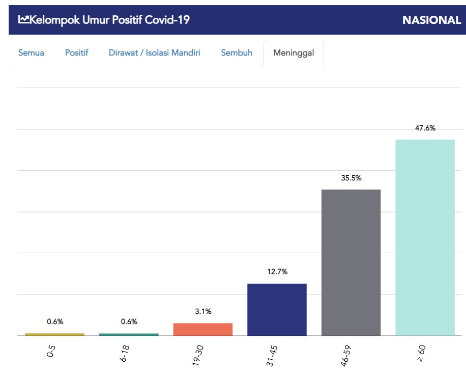

Selain itu, pada kasus positif COVID-19 dan sedang dirawat atau isolasi, proporsi penduduk berjenis kelamin perempuan lebih banyak dibandingkan laki-laki (Kemenkes, 2021). Tingkat kerentanan sosial masyarakat telah banyak dilakukan melalui indeks kerentanan sosial. **Kerentanan sosial wilayah menggambarkan kerapuhan sosial dari suatu wilayah akibat pengaruh dari adanya bahaya**. Faktor-faktor kerentanan sosial menjadi salah satu hal yang krusial di tengah pandemi COVID-19. Hal ini dikarenakan gabungan faktor kerentanan sosial tersebut dapat meningkatkan risiko terkena COVID-19.

### Tujuan

Untuk mengetahui kelompok yang memiliki resiko lebih tinggi (rentan) dan seberapa cepat pulih terhadap dampak COVID-19 menjadi penting, mengingat hal ini dapat meningkatkan kesadaran, mencegah terinfeksi COVID-19, dan menurunkan tingkat kematian.

### Dataset

Sumber data yang digunakan untuk melakukan analisis ini bersumber dari:

- *Website Open* Data DKI Jakarta berupa variabel:
  - persentase penduduk perempuan,
  - persentase kepala keluarga berjenis kelamin perempuan,
  - persentase penduduk lansia,
  - persentase pengangguran,
  - persentase penduduk wajib KTP,
  - jumlah daerah rawan banjir,
  - persentase pekerja di sektor informal, dan
  - jumlah puskesmas.
- *Website Open* Data COVID-19 Provinsi DKI Jakarta berupa variabel:
  - jumlah kasus positif COVID-19,
  - jumlah penduduk yang dirawat akibat COVID-19, dan
  - jumlah penduduk yang melakukan isolasi mandiri akibat COVID-19.
- Publikasi Kabupaten/Kota dalam Angka oleh BPS untuk setiap kota dan kabupaten di Provinsi DKI Jakarta berupa variabel:
  - jumlah RS umum

## *Theoretical Concept*

### Multivariate Analysis

Multivariate analysis adalah sekelompok metode statistik yang berfokus pada mempelajari banyak variabel bersama-sama sambil berfokus pada variasi yang dimiliki oleh variabel-variabel tersebut.

> *Multivariate Statistics deals with the treatment of data sets with a large number of dimensions.*

### Analisis Faktor / *Factor Analysis*

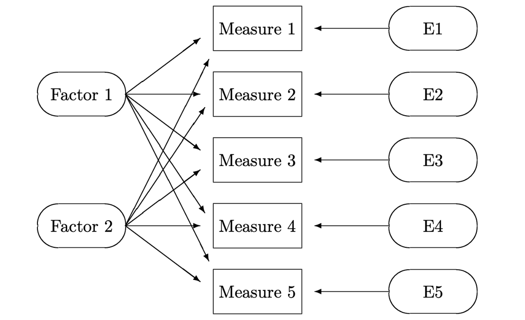

Analisis faktor bertujuan untuk menerangkan struktur ragam-peragam melalui kombinasi linier dari variabel-variabel pembentuknya. Pada dasarnya, analisis faktor mendekatkan data pada suatu pengelompokkan berdasarkan adanya keeratan hubungan antar-dimensi pembentuk faktor. Statistik kunci yang relevan dengan analisis faktor antara lain

#### *Bartletts test of sphericity*

*Bartletts test of sphericity* yaitu suatu uji statistik yang dipergunakan untuk menguji hipotesis bahwa variabel tidak saling berkorelasi dalam populasi. Statistik uji Bartlett adalah sebagai berikut:

$$\chi^2= -[(N-1)-\frac{2p+5}{6}] ln|R|$$
dengan $N$ merupakan jumlah observasi, $p$ merupakan jumlah variabel, dan $|R|$ merupakan determianan matriks korelasi.

#### *Kaiser-Meyer-Olkin (KMO)*

KMO adalah uji yang dilakukan untuk menentukan kelayakan (appropriateness) dari suatu analisis faktor yang akan dilakukan. Skala uji KMO berkisar antara 0 sampai 1. Jika nilai KMO hitung lebih rendah dari 0.5, maka analisis faktor tidak layak dilakukan. Sedangkan jika nilai KMO hitung lebih besar dari 0.5, maka analisis faktor layak dilakukan. Statistik Uji Kaiser-Meyer-Olkin adalah sebagai berikut:

$$KMO = \frac {\sum\sum_{j≠k} r^2_{jk}}{\sum\sum_{j≠k}r^2_{jk} + \sum\sum_{j≠k}p^2_{jk}}$$
di mana: - $r_{jk}$ = koefisien korelasi antara variabel ke-j dan ke-k - $p_{jk}$ = koefisien korelasi parsial antara variabel ke-j dan ke-k

#### *Measure of Sampling Adequacy (MSA)*

*Measure of Sampling Adequacy* (MSA) yaitu suatu indeks perbandingan natara koefisien korelasi parsial untuk setiap variabel. MSA digunakan untuk mengukur kecukupan sampel.

### *Principal Component Analysis* (PCA)

PCA merupakan suatu algoritma unsupervised learning yang bertujuan untuk *dimentionality reduction*. Salah satu tujuan dari PCA adalah untuk mengubah variabel asli yang saling berkorelasi satu sama lainnya menjadi satu set variabel baru yang memiliki korelasi lebih kecil atau saling bebas.

Ide dasar dari PCA adalah untuk membuat sumbu (axis) baru yang dapat menangkap informasi sebesar mungkin. Sumbu baru ini adalah yang dinamakan sebagai **Principal Component (PC)**. Untuk melakukan dimensionality reduction, kita akan memilih beberapa PC untuk dapat merangkum informasi yang dibutuhkan. Nilai masing-masing PC dibentuk dari matriks varian-kovarians dari suatu set variabel melalui kombinasi linear dari variabel-variabel tersebut.

$$PC1 = a_{11}x_1 + a_{12}x_2 + ... + a_{1p}x_p$$
di mana: - vektor **$a_1$** adalah eigen vector dari suatu matriks varian kovarians - Nilai $x_i$ adalah nilai suatu data pada baris ke-i

Hal-hal yang menjadi pedoman dalam menentukan jumlah PC, yaitu: 1. Mempertahankan PC yang cukup untuk menjelaskan persentase yang spesifik dari total variansi/informasi 2. Mempertahankan PC yang memiliki eigen value lebih besar dibandingkan rata-rata eigen value dari setiap PC

## Load Packages

Berikut merupakan basic packages yang digunakan selama pengerjaan analisis:

```r
library(readr) # untuk membaca data
library(dplyr) # untuk data manipulation
library(GGally) # untuk membuat matriks korelasi
library(psych) #
library(corrplot) #
library(ggplot2)
library (GPArotation)
library(factoextra) # for model comparison and assumption check)
library(gridExtra)
library(tidyr)
library(rmdformats)
```

## Data Loading

Pada project ini, dilakukan observasi pada level kecamatan dengan jumlah observasi sebanyak 44 kecamatan di Provinsi DKI Jakarta. Hal ini diakibatkan observasi level kecamatan memiliki data yang terbaru dan paling lengkap. Adapun variabel yang digunakan berasal dari berbagai sumber yang telah disebutkan di atas. Berikut adalah 12 variabel yang digunakan:

```r
rentan <- readxl::read_xlsx("dataset/kerentanansosial.xlsx")
rmarkdown::paged_table(rentan)
```

| Kecamatan | perempuan | KK_perempuan | lansia | pengangguran | wajib_ktp | banjir | informal | RS | puskesmas | positiv_cov | rawat | isoman |
| --- | --- | --- | --- | --- | --- | --- | --- | --- | --- | --- | --- | --- |
| Cakung | 49.2096 | 18.05886 | 6.217495 | 0.5319820 | 70.20066 | 31 | 6.503218 | 1 | 9 | 11740 | 82 | 102 |
| Cempaka Putih | 50.0816 | 23.00326 | 10.852327 | 0.5383420 | 75.12540 | 0 | 13.910844 | 2 | 4 | 4998 | 50 | 17 |
| Cengkareng | 49.3437 | 18.54968 | 6.585898 | 0.5156924 | 70.84496 | 55 | 6.791649 | 1 | 10 | 13036 | 109 | 146 |
| Cilandak | 50.4252 | 20.79268 | 9.310706 | 0.2667300 | 73.73298 | 2 | 10.869546 | 3 | 6 | 8201 | 62 | 114 |
| Cilincing | 49.4534 | 20.51346 | 5.975218 | 0.6526999 | 68.92114 | 38 | 11.266610 | 1 | 10 | 7899 | 73 | 63 |
| Cipayung | 49.6205 | 17.12363 | 7.000645 | 0.8710592 | 71.17214 | 15 | 14.258273 | 0 | 11 | 10437 | 63 | 124 |
| Ciracas | 49.6704 | 18.68758 | 7.754256 | 0.6041091 | 71.58468 | 8 | 7.188402 | 1 | 6 | 9529 | 73 | 108 |
| Duren Sawit | 50.1246 | 19.61388 | 9.273389 | 0.4812955 | 72.23915 | 2 | 6.425025 | 2 | 12 | 14329 | 139 | 145 |
| Gambir | 49.5283 | 25.08302 | 13.219493 | 0.6956280 | 76.54174 | 0 | 20.020030 | 1 | 4 | 3796 | 25 | 42 |
| Grogolpetamburan | 50.2681 | 22.92100 | 11.359290 | 0.5001664 | 75.13739 | 28 | 15.082484 | 3 | 10 | 8298 | 67 | 43 |

[output cut: 34 more lines]

Berikut adalah deskripsi data untuk `rentan`:

- `Kecamatan` = Nama kecamatan pada masing-masing kota administratif pada Provinsi DKI Jakarta
- `perempuan` = persentase penduduk perempuan
- `KK_perempuan` = persenyase kepala keluarga berjenis kelamin perempuan
- `lansia` = persentase penduduk lansia
- `pengangguran` = persentase pengangguran
- `wajib_ktp` = persentase penduduk wajib KTP
- `banjir` = jumlah daerah rawan banjir
- `informal` = persentase pekerja di sektor informal
- `RS` = jumlah RS umum
- `puskesmas` = jumlah puskesmas
- `positif_cov` = jumlah kasus positif akibat COVID-19 (data 30 april 2021)
- `rawat` = jumlah penduduk yang dirawat akibat COVID-19
- `isoman` = jumlah penduduk yang melakukan isolasi mandiri akibat COVID-19 (data 30 april 2021)

## Data Wrangling

```r
glimpse(rentan)
```

```
#> Rows: 44
#> Columns: 13
#> $ Kecamatan    <chr> "Cakung", "Cempaka Putih", "Cengkareng", "Cilandak", "Cil…
#> $ perempuan    <dbl> 49.2096, 50.0816, 49.3437, 50.4252, 49.4534, 49.6205, 49.…
#> $ KK_perempuan <dbl> 18.05886, 23.00326, 18.54968, 20.79268, 20.51346, 17.1236…
#> $ lansia       <dbl> 6.217495, 10.852327, 6.585898, 9.310706, 5.975218, 7.0006…
#> $ pengangguran <dbl> 0.5319820, 0.5383420, 0.5156924, 0.2667300, 0.6526999, 0.…
#> $ wajib_ktp    <dbl> 70.20066, 75.12540, 70.84496, 73.73298, 68.92114, 71.1721…
#> $ banjir       <dbl> 31, 0, 55, 2, 38, 15, 8, 2, 0, 28, 12, 32, 2, 0, 4, 4, 0,…
#> $ informal     <dbl> 6.503218, 13.910844, 6.791649, 10.869546, 11.266610, 14.2…
#> $ RS           <dbl> 1, 2, 1, 3, 1, 0, 1, 2, 1, 3, 3, 2, 0, 1, 3, 2, 4, 2, 1, …
#> $ puskesmas    <dbl> 9, 4, 10, 6, 10, 11, 6, 12, 4, 10, 6, 12, 7, 13, 11, 9, 8…
#> $ positiv_cov  <dbl> 11740, 4998, 13036, 8201, 7899, 10437, 9529, 14329, 3796,…
#> $ rawat        <dbl> 82, 50, 109, 62, 73, 63, 73, 139, 25, 67, 80, 55, 25, 73,…
#> $ isoman       <dbl> 102, 17, 146, 114, 63, 124, 108, 145, 42, 43, 175, 87, 19…
```

## Exploratory Data Analysis

Sebelum dilakukannya analisis lebih lanjut, alangkah lebih baik kita mengeksplorasi data kerentanan sosial dalam bentuk visualisasi.

### 1. Melakukan pengecekan missing value

```r
colSums(is.na(rentan))
```

```
#>    Kecamatan    perempuan KK_perempuan       lansia pengangguran    wajib_ktp
#>            0            0            0            0            0            0
#>       banjir     informal           RS    puskesmas  positiv_cov        rawat
#>            0            0            0            0            0            0
#>       isoman
#>            0
```

### 2. Gambaran umum variabel penyusun indeks kerentanan sosial

```r
summary(rentan)
```

```
#>   Kecamatan           perempuan      KK_perempuan       lansia
#>  Length:44          Min.   :49.11   Min.   :14.78   Min.   : 5.873
#>  Class :character   1st Qu.:49.43   1st Qu.:18.93   1st Qu.: 7.844
#>  Mode  :character   Median :49.67   Median :21.11   Median : 8.845
#>                     Mean   :49.73   Mean   :21.09   Mean   : 8.997
#>                     3rd Qu.:49.98   3rd Qu.:22.94   3rd Qu.: 9.776
#>                     Max.   :50.98   Max.   :27.49   Max.   :13.219
#>   pengangguran      wajib_ktp         banjir         informal
#>  Min.   :0.1950   Min.   :67.78   Min.   : 0.00   Min.   : 6.148
#>  1st Qu.:0.3217   1st Qu.:71.57   1st Qu.: 0.00   1st Qu.: 9.543
#>  Median :0.5162   Median :72.66   Median : 9.00   Median :10.540
#>  Mean   :0.5611   Mean   :72.78   Mean   :12.86   Mean   :12.412
#>  3rd Qu.:0.6276   3rd Qu.:73.73   3rd Qu.:18.75   3rd Qu.:16.318
#>  Max.   :1.7709   Max.   :79.05   Max.   :59.00   Max.   :25.738
#>        RS          puskesmas      positiv_cov        rawat
#>  Min.   :0.000   Min.   : 3.00   Min.   :  242   Min.   :  0.00
#>  1st Qu.:1.000   1st Qu.: 6.00   1st Qu.: 5698   1st Qu.: 49.75
#>  Median :1.500   Median : 7.50   Median : 7966   Median : 62.50
#>  Mean   :1.818   Mean   : 7.75   Mean   : 7587   Mean   : 65.61
#>  3rd Qu.:3.000   3rd Qu.: 9.25   3rd Qu.: 9622   3rd Qu.: 77.00
#>  Max.   :7.000   Max.   :14.00   Max.   :14329   Max.   :142.00
#>      isoman
#>  Min.   :  0.00
#>  1st Qu.: 41.75
#>  Median : 62.50
#>  Mean   : 67.93
#>  3rd Qu.: 88.50
#>  Max.   :175.00
```

```r
rentan[which(rentan$pengangguran < 0.1951 | rentan$pengangguran > 1.770), ]
```

```
#> # A tibble: 2 × 13
#>   Kecamatan  perem…¹ KK_pe…² lansia penga…³ wajib…⁴ banjir infor…⁵    RS puske…⁶
#>   <chr>        <dbl>   <dbl>  <dbl>   <dbl>   <dbl>  <dbl>   <dbl> <dbl>   <dbl>
#> 1 Kembangan     49.8    17.7   8.30   0.195    71.8      0    9.49     1       9
#> 2 Kepulauan…    49.3    14.8   6.43   1.77     67.8      0    8.56     0       4
#> # … with 3 more variables: positiv_cov <dbl>, rawat <dbl>, isoman <dbl>, and
#> #   abbreviated variable names ¹perempuan, ²KK_perempuan, ³pengangguran,
#> #   ⁴wajib_ktp, ⁵informal, ⁶puskesmas
#> # ℹ Use `colnames()` to see all variable names
```

Berdasarkan hasil `summary(rentan)`, secara umum terdapat 49,73 persen jumlah penduduk perempuan yang ditunjukan oleh rata-rata `perempuan` dengan 21,09 persen merupakan kepala keluarga yang berjenis kelamin perempuan dari variabel `KK_perempuan`. Sedangkan untuk rata-rata jumlah penduduk lansia di Jakarta sebesar 8,997 persen yang ditunjukan oleh `lansia`.

Kemudian untuk variabel `pengangguran`, secara rata-rata sebesar 0,5611 persen dengan nilai maksimum 1,77 persen berada di Kecamatan Kep. Seribu Selatan dan nilai terendah 0,195 berada di Kecamatan Kembangan. Perbedaan antara nilai maksimum dan minimum yang hampir 10 kali lipat ini menunjukkan belum meratanya tingkat pengangguran di DKI Jakarta. Selain itu, terdapat 12,412 persen pekerja informal di DKI Jakarta.

Membahas lebih lanjut lagi mengenai variabel yang digunakan dalam penelitian ini, KTP merupakan salah satu dokumen administrasi yang sangat penting dan harus dimiliki seluruh masyarakat Indonesia. Tanpa adanya kepemilikan dokumen ini, maka akan terjadi kesulitan dalam menggunakan berbagai layanan publik, seperti kesehatan, perbankan, pendidikan, pendataan pemerintah, dan lain sebagainya. Namun, persentase penduduk wajib KTP di DKI Jakarta yang ditunjukkan oleh `wajib_KTP` secara umum hanya sebesar 72,78 persen, yang menandakan belum semua masyarakat sadar akan pentingnya kepemilikan KTP.

Dari hasil `summary()`, diketahui bahwa setiap variabel memiliki range nilai yang cukup berbeda, hal ini menyebabkan data yang dimiliki perlu untuk dilakukan scaling/standardisasi.

### Melihat visualisasi antar beberapa variabel

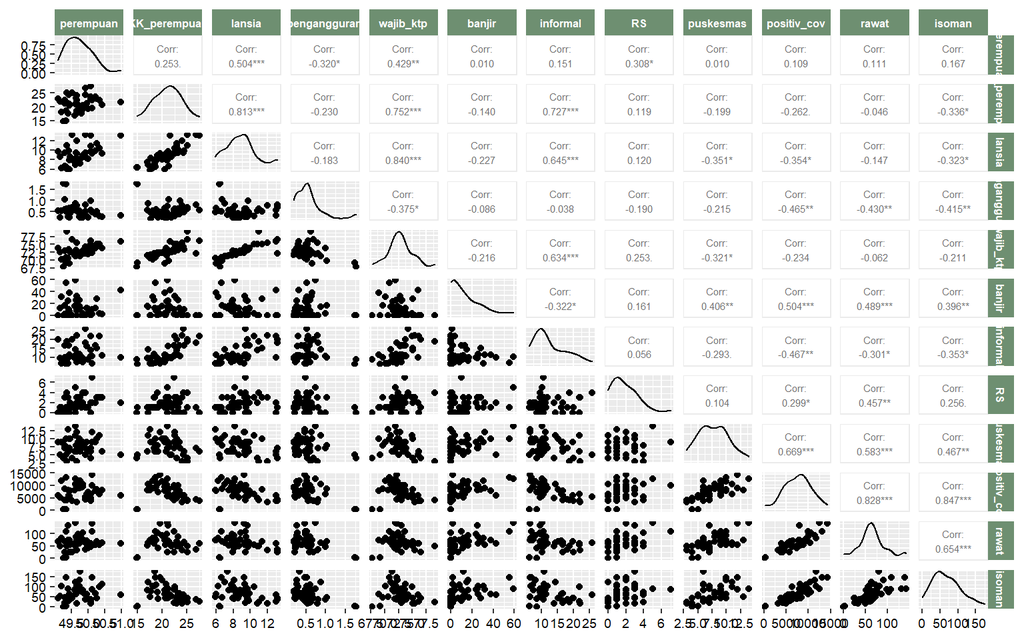

```r
ggpairs(rentan[,c(2:13)], showStrips = F, upper = list(continuous = wrap("cor", size=2))) +
  theme(axis.text = element_text(colour = "black", size = 7),
        strip.background = element_rect(fill = "#6e8f71"),
        strip.text = element_text(colour = "white", size = 6,
                                  face = "bold"))
```

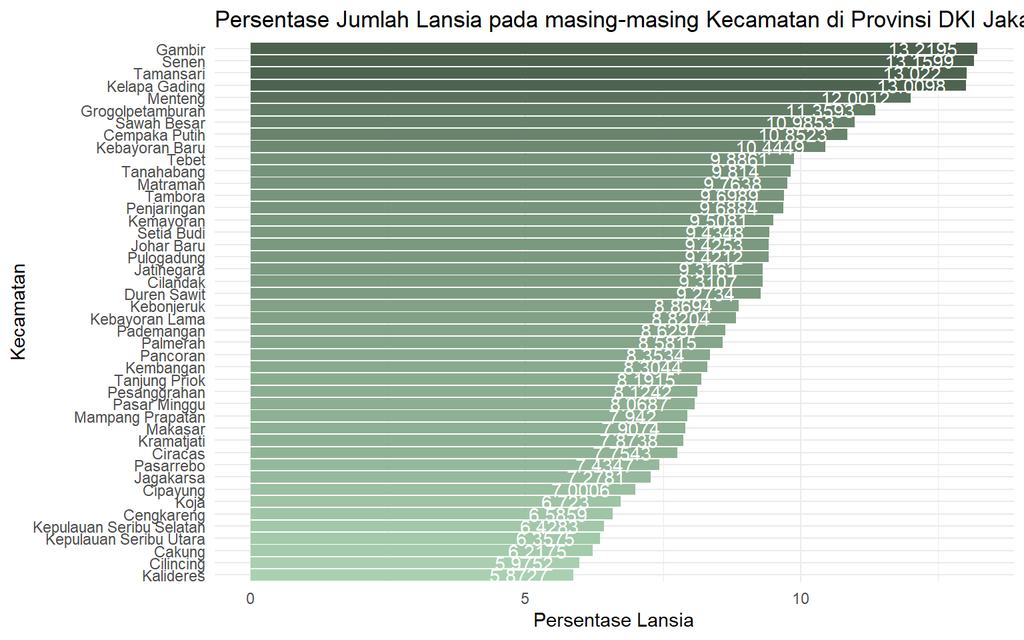

```r
ggplot(data = rentan, mapping = aes(x=  lansia, y= reorder(Kecamatan,lansia))) +
  geom_col(aes(fill = lansia))  + # untuk membuat barplot
  labs(
    title = "Persentase Jumlah Lansia pada masing-masing Kecamatan di Provinsi DKI Jakarta",
    x = "Persentase Lansia",
    y = "Kecamatan"
  ) +
  scale_fill_gradient(low = "#a9d1b1", high = "#4c614e") +
  geom_text(mapping = aes(label=round(lansia, digits = 4)), # menambahkan informasi label masing-masing kategori dengan variasi box
            col = "white", # memberikan warna pada text
            nudge_x = -1, # menggeser text berdasarkan sumbu x
            label.size = 12) +
  theme_minimal() +
  theme(legend.position = "none") # untuk menghilangkan legend.
```

## Penyusun Kerentanan Sosial

Pada bagian ini dilakukan tiga teknik analisis untuk melihat bagaimana kerentanan sosial yang diakibatkan COVID-19. 1. Digunakan metode *Factor Analysis* untuk membentuk indeks kerentanan sosial per kecamatan di DKI Jakarta. 2. Kemudian melakukan pengklusteran menggunakan metode non-hierarchical clustering 3. Uji Kruskal-Wallis untuk mengetahui bagimana variabel mempengaruhi kerentanan sosial pada masing-masing klaster.

### Factor Analysis / Analisis Faktor

Sebelum dilakukan analisis faktor pada data kerentanan sosial, perlu dilakukan beberapa pengujian validitas untuk memutuskan apakah data yang dimiliki sudah memenuhi syarat untuk dianalisis menggunakan analisis faktor.

#### Melakukan uji multikolinearitas pada seluruh variabel.

Tujuan dari membentuk plot korelasi adalah untuk menguji kolinearitas dari data. Seluruh variabel harus memiliki korelasi, tetapi tidak terlalu tinggi.

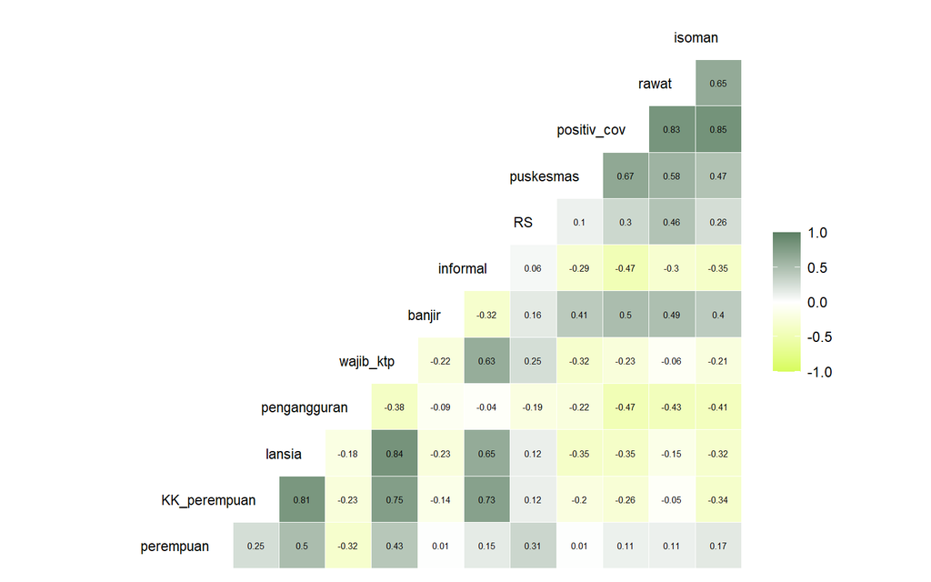

```r
ggcorr(rentan, label = T, hjust = 1, layout.exp = 2, size = 3, label_size = 2, label_round = 2, low = "#d7fc5b", mid = "white", high = "#5d8064")
```

Correlation plot di atas yang digunakan untuk menguji multikolinearitas dari data. Pada project ini, digunakan batas (>0,85) sebagai batas korelasi ekstrem terhadap setiap variabel. Dapat dilihat bahwa semua variabel tidak memiliki nilai korelasi yang lebih dari 0,85.

#### *Kaiser–Meyer–Olkin* (KMO) - *Measure of Sampling Adequacy*(MSA)

Untuk dapat melakukan pengujian KMO dan MSA, pada R disediakan suatu function `KMO()` dari library `psych`.

```r
rentan_cor <- cor(rentan[,2:13])
rentan_KMO<-KMO(rentan_cor)
```

Melakukan inspeksi nilai KMO

```r
rentan_KMO$MSA
```

```
#> [1] 0.7315378
```

Untuk nilai KMO didapatkan sebesar 0,7315378. Syarat dapat dilanjutkannya proses analisis faktor adalah nilai KMO lebih besar dari nilai 0,5. Dari hasil tersebut dapat dikatakan bahwa proses analisis faktor bisa dilanjutkan ke proses selanjutnya karena syarat dilanjutkannya proses analisis faktor terpenuhi.

Melakukan inspeksi nilai MSA masing-masing variabel

```r
as.data.frame(rentan_KMO$MSAi)
```

```
#>              rentan_KMO$MSAi
#> perempuan          0.5668812
#> KK_perempuan       0.7179420
#> lansia             0.7098078
#> pengangguran       0.7076842
#> wajib_ktp          0.7910448
#> banjir             0.9167223
#> informal           0.7308076
#> RS                 0.5590642
#> puskesmas          0.7816397
#> positiv_cov        0.7193430
#> rawat              0.8068755
#> isoman             0.7060883
```

Dari hasil output nilai MSA masing-masing variabel di atas didapatkan seluruh nilai MSA dari setiap variabel (> 0,5). Sehingga bisa dinyatakan bahwa semua variabel dapat diprediksi dan dianalisis lebih lanjut

#### *The Bartlett’s Test statistics*

Bartlett’s test digunakan untuk mengkonfirmasi bahwa data berkorelasi secara berpasangan (Mickey & Sharma, 1997). Dengan kata lain uji bartlett digunakan untuk mengetahui homogenitas variance.

- Hipotesis uji
  - H0 = Varians di antara masing-masing variabel adalah sama (variance homogen)
  - H1 = Setidaknya satu variabel memiliki varians yang tidak sama dengan yang lain (variance tidak homogen)
- Pengujian yang diharapkan adalah data memiliki variance yang tidak homogen (tolak H0).

```r
bartlett.test(rentan[,2:13])
```

```
#>
#>  Bartlett test of homogeneity of variances
#>
#> data:  rentan[, 2:13]
#> Bartlett's K-squared = 5144, df = 11, p-value < 0.00000000000000022
```

Hasil perhitungan dengan R dihasilkan nilai Bartlett test of homogeneity variances sebesar 5144 dengan signifikansi sebesar 0,000. Dengan demikian, Bartlett test of homogeneity of variances memenuhi persyaratan karena signifikansi di bawah 0,05 (5%), sehingga variance tidak homogen.

#### Membentuk faktor-faktor penyusun kerentanan sosial

Untuk melakukan exploratory factor analysis menggunakan MinRes (Minimum Residual), fungsi yang tersedia di R adalah `fa()` dari library `psych`.

Parameter fungsi `fa()` - `r`: Correlation/covariance matrix dari data awal

```r
fa_rentan <- fa(r = rentan_cor)
fa_rentan
```

```
#> Factor Analysis using method =  minres
#> Call: fa(r = rentan_cor)
#> Standardized loadings (pattern matrix) based upon correlation matrix
#>                MR1    h2   u2 com
#> perempuan    -0.11 0.013 0.99   1
#> KK_perempuan -0.59 0.352 0.65   1
#> lansia       -0.68 0.459 0.54   1
#> pengangguran -0.16 0.026 0.97   1
#> wajib_ktp    -0.58 0.334 0.67   1
#> banjir        0.51 0.260 0.74   1
#> informal     -0.69 0.480 0.52   1
#> RS            0.13 0.018 0.98   1
#> puskesmas     0.63 0.402 0.60   1
#> positiv_cov   0.85 0.721 0.28   1
#> rawat         0.64 0.406 0.59   1
#> isoman        0.72 0.519 0.48   1
#>
#>                 MR1
#> SS loadings    3.99
#> Proportion Var 0.33
#>
#> Mean item complexity =  1
#> Test of the hypothesis that 1 factor is sufficient.
#>
#> The degrees of freedom for the null model are  66  and the objective function was  9.27
#> The degrees of freedom for the model are 54  and the objective function was  5.98
#>
#> The root mean square of the residuals (RMSR) is  0.23
#> The df corrected root mean square of the residuals is  0.26
#>
#> Fit based upon off diagonal values = 0.66
#> Measures of factor score adequacy
#>                                                    MR1
#> Correlation of (regression) scores with factors   0.96
#> Multiple R square of scores with factors          0.91
#> Minimum correlation of possible factor scores     0.83
```

Secara default, objek factor analysis yang terbentuk menghasilkan sejumlah 1 faktor. Jumlah ini dapat saja belum optimal, sehingga perlu untuk mencari jumlah faktor yang optimal dari data yang kita miliki.

Salah satu cara untuk mencari jumlah faktor yang optimal dari data, digunakan sebuah fungsi yaitu `fa.parallel()`. Metode ini mencari jumlah faktor optimal dari nilai eigen yang berurutan, kemudian penurunan tajam dalam plot menunjukkan jumlah komponen atau faktor yang sesuai untuk diekstraksi.

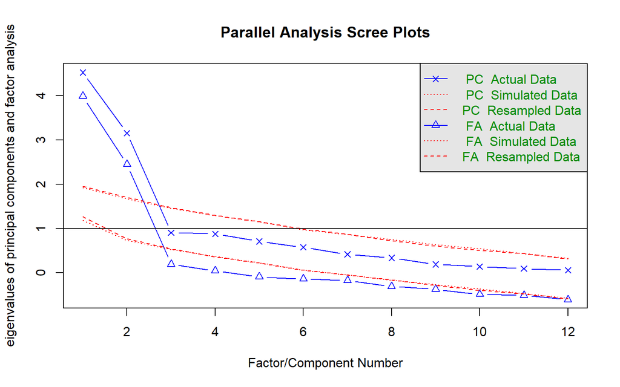

```
#> Parallel analysis suggests that the number of factors =  2  and the number of components =  2
```

```r
nfactors <- fa.parallel(rentan[,2:13], plot = T)
```

```r
summary(nfactors)
```

Dari hasil paralell analysis scree plot di atas dihasilkan `factors=2` sebagai jumlah faktor yang optimal pada data rentan.

Selanjutnya akan kembali dilakukan analisis faktor menggunakan jumlah faktor optimal yang sudah didapatkan. Parameter tambahan fungsi `fa()` - `nfactors`: banyaknya faktor yang akan dibentuk - `rotate` : tipe rotasi. Rotasi meminimalkan kompleksitas faktor untuk membuat struktur lebih sederhana untuk ditafsirkan.

```r
# jumlah faktor optimal yang didapat
nfact <- nfactors$nfact

#factor analysis
fa_rentan_opt <- fa(r = rentan_cor, nfactors = nfact, rotate = "varimax")
fa_rentan_opt
```

```
#> Factor Analysis using method =  minres
#> Call: fa(r = rentan_cor, nfactors = nfact, rotate = "varimax")
#> Standardized loadings (pattern matrix) based upon correlation matrix
#>                MR1   MR2   h2      u2 com
#> perempuan     0.22  0.48 0.27 0.72599 1.4
#> KK_perempuan -0.15  0.83 0.71 0.29360 1.1
#> lansia       -0.21  0.91 0.88 0.12095 1.1
#> pengangguran -0.50 -0.37 0.38 0.61504 1.8
#> wajib_ktp    -0.08  0.93 0.87 0.12878 1.0
#> banjir        0.50 -0.17 0.28 0.72403 1.2
#> informal     -0.36  0.66 0.56 0.43507 1.5
#> RS            0.38  0.27 0.22 0.78159 1.8
#> puskesmas     0.61 -0.22 0.42 0.57622 1.3
#> positiv_cov   0.99 -0.17 1.00 0.00042 1.1
#> rawat         0.88  0.03 0.77 0.22694 1.0
#> isoman        0.80 -0.15 0.66 0.33818 1.1
#>
#>                        MR1  MR2
#> SS loadings           3.65 3.39
#> Proportion Var        0.30 0.28
#> Cumulative Var        0.30 0.59
#> Proportion Explained  0.52 0.48
#> Cumulative Proportion 0.52 1.00
#>
#> Mean item complexity =  1.3
#> Test of the hypothesis that 2 factors are sufficient.
#>
#> The degrees of freedom for the null model are  66  and the objective function was  9.27
#> The degrees of freedom for the model are 43  and the objective function was  1.6
#>
#> The root mean square of the residuals (RMSR) is  0.05
#> The df corrected root mean square of the residuals is  0.07
#>
#> Fit based upon off diagonal values = 0.98
```

Dari output di atas dengan menggunakan faktor sebanyak 2 didapatkan beberapa informasi sebagai berikut:

- 1. `SS Loadings`: Nilai Eigen.
- 2. `Proportion Var`: Memberitahu kita berapa banyak varians/informasi keseluruhan yang diperhitungkan faktor dari semua variabel.
- 3. `Cumulative Var`: Nilai akumulasi dari proportion var.
- 4. `Proportion Explained`: Jumlah variansi relatif yang terjelaskan. Merupakan pembagian dari proportion var/ sum(proportion var).
- 5. `Cumulative Proportion`: Jumlah akumulasi dari proportion explained.
- 6. `MR`: Minimum Residual/factor dapat disebut juga sebagai komponen utama.
- 7. `h2`: jumlah varians dalam item/variabel yang dijelaskan oleh faktor-faktor (yang dipertahankan). Ekuivalen dengan SS Loadings untuk variabel / communality
- 8. `u2`: merupakan nilai 1-`h2` adalah residual variance.
- 9. `com`: item complexity.

> Dengan menggunakan 2 faktor, maka informasi keseluruhan yang diperhitungkan faktor dari semua variabel sebanyak 0,59 atau 59%.

#### Pengekstrakan variabel laten

Salah satu tujuan dari factor analysis adalah melakukan ekstraksi dengan menghasilkan variabel laten.

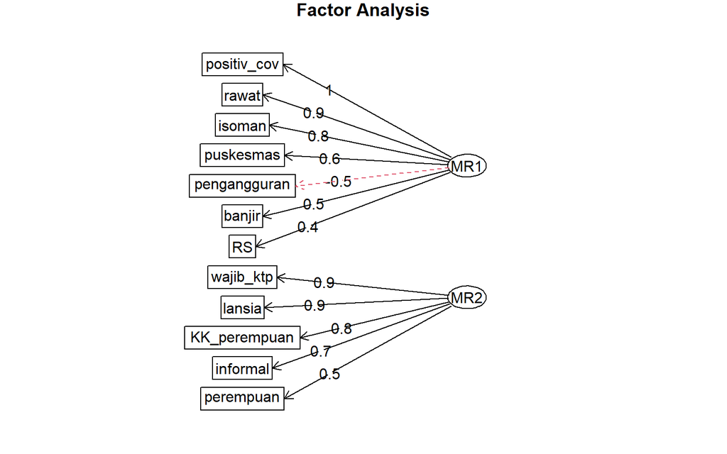

```r
fa.diagram(fa_rentan_opt, rsize = 1)
```

Dari plot di atas dilakukan pengekstrakan terhadap 2 faktor/ komponen utama, yaitu kesehatan dan kependudukan.

Arah dari masing-masing variabel ditentukan berdasarkan kajian literatur dari (Rufat et al., 2015), dimana arah tersebut ditentukan berdasarkan pengaruhnya terhadap kerentanan sosial. Arah positif berpengaruh terhadap peningkatan kerentanan sosial, sebaliknya arah negatif menurunkan tingkat kerentanan sosial.

### Indeks Kerentanan Sosial

Ada banyak metode untuk melakukan pembobotan dalam agregasi indeks. Peneliti seperti: - (Cutter et al., 2003) menggunakan pembobot tertimbang, - (Solangaarachchi et al., 2012) menggunakan pembobot berdasarkan kontribusi terhadap varians terjelaskan, - (Siagian et al., 2014) menggunakan pembobot tidak sama, dan - (Rygel et al., 2006) menggunakan pareto-ranking. Tidak ada kesepakatan yang membatasi penggunaan pembobotan yang berbeda.

Dalam project ini, digunakan pembobotan tidak sama untuk melakukan agregasi indeks. Pembobot didapatkan dari **pembagian antara varians terjelaskan masing-masing komponen dibagi dengan total varians terjelaskan** atau nilai **`proportion explained`** dari object `fa_rentan_opt`. Dengan cara ini komponen yang memiliki varians terjelaskan yang lebih tinggi berpengaruh lebih besar terhadap kerentanan sosial. Perhitungan kerentanan sosial mengikuti persamaan sebagai berikut:

$$SoVI=(0.52*komponen1)+(0.48*komponen2)$$
SoVI merujuk peda Social Vulnarability Index.

### Melakukan PCA pada data `rentan`

PCA bertujuan untuk melakukan reduksi data dari sekumpulan variabel (Mickey & Sharma, 1997). Pada analisis ini, PCA digunakan untuk menghitung nilai SoVI masing-masing kecamatan yang ada pada dataset. Untuk itu akan dilakukan inspeksi untuk `pca$x` dimana merupakan nilai hasil proyeksi titik ke PC untuk tiap baris. Digunakan untuk mendapatkan nilai data yang baru.

```r
rentan_pca<-prcomp(rentan[,2:13], scale. = T)
as.data.frame(rentan_pca$x)
```

```
#>             PC1         PC2         PC3         PC4           PC5         PC6
#> 1  -3.114698313  1.16146402  0.70269465 -0.26874313  0.0794717464 -0.83040321
#> 2   2.632146881 -0.42156484 -0.90543834  0.07808155 -0.1517103706 -0.35236376
#> 3  -4.238011186 -0.08712318  1.29850785  0.14894931 -0.7825611874 -1.34008534
#> 4   0.001011035 -1.44360415 -2.13200783 -0.47279341 -0.0727652791 -0.02147124
#> 5  -1.990459049  1.41993010  1.38336399  0.44264881 -0.6316739034 -0.05627611
#> 6  -1.991088213  1.12805863  0.40352973 -0.67822043 -0.3714596095  1.04697530
#> 7  -1.348935899  0.80785729 -0.87997822 -0.62237952  0.1099264600 -0.57502800
#> 8  -3.173103400 -1.92644731 -0.69547699 -0.76809952  0.1343531710  1.29038347
#> 9   4.073082656 -0.39883469  0.56347942 -0.21943214  0.1566684871 -0.56750799
#> 10  0.735666288 -2.06440934  0.23443815  0.84889817 -1.1590608663  0.53255003
#> 11 -2.400769508 -0.64597328 -1.42372253 -0.41530807  0.9051997016 -0.71208466
#> 12 -0.960349089 -0.52145148  1.14697993  0.40918965 -0.8243627760  0.47926894
#> 13  2.131314518  1.46458552  1.01262467 -0.80879142  0.2356564578  0.03993871
#> 14 -2.062338525  1.68013622  0.25867759 -0.94352775  0.6319447458  1.34273568
```

[output cut: 75 more lines]

Sesuai dengan hasil dari factor analysis, akan kita ambil sebanyak 2 principal component untuk kebutuhan pemetaan SoVI masing-masing kecamatan di Provinsi DKI Jakarta.

```r
pc_keep <- rentan_pca$x[, 1:2] %>%
  as.data.frame()
pc_keep
```

```
#>             PC1         PC2
#> 1  -3.114698313  1.16146402
#> 2   2.632146881 -0.42156484
#> 3  -4.238011186 -0.08712318
#> 4   0.001011035 -1.44360415
#> 5  -1.990459049  1.41993010
#> 6  -1.991088213  1.12805863
#> 7  -1.348935899  0.80785729
#> 8  -3.173103400 -1.92644731
#> 9   4.073082656 -0.39883469
#> 10  0.735666288 -2.06440934
#> 11 -2.400769508 -0.64597328
#> 12 -0.960349089 -0.52145148
#> 13  2.131314518  1.46458552
#> 14 -2.062338525  1.68013622
```

[output cut: 30 more lines]

Selanjutnya, dilakukan pengabungan nilai hasil Principal Component dengan nama-nama kecamatan yang ada pada dataset `rentan`.

```r
rentan_new <- rentan %>%
  select_if(~!is.numeric(.)) %>% # ambil kolom Kecamatan
  cbind(pc_keep) # gabungkan dengan kolom PC
rentan_new
```

```
#>                   Kecamatan          PC1         PC2
#> 1                    Cakung -3.114698313  1.16146402
#> 2             Cempaka Putih  2.632146881 -0.42156484
#> 3                Cengkareng -4.238011186 -0.08712318
#> 4                  Cilandak  0.001011035 -1.44360415
#> 5                 Cilincing -1.990459049  1.41993010
#> 6                  Cipayung -1.991088213  1.12805863
#> 7                   Ciracas -1.348935899  0.80785729
#> 8               Duren Sawit -3.173103400 -1.92644731
#> 9                    Gambir  4.073082656 -0.39883469
#> 10         Grogolpetamburan  0.735666288 -2.06440934
#> 11                Jagakarsa -2.400769508 -0.64597328
#> 12               Jatinegara -0.960349089 -0.52145148
#> 13               Johar Baru  2.131314518  1.46458552
#> 14                Kalideres -2.062338525  1.68013622
```

[output cut: 30 more lines]

Melakukan perhitungan persamaan indeks kerentanan sosial.

```r
rentan_new <- rentan_new %>%
  mutate(SoVI = 0.52*abs(PC1) + 0.48*abs(PC2))
rentan_new
```

```
#>                   Kecamatan          PC1         PC2      SoVI
#> 1                    Cakung -3.114698313  1.16146402 2.1771459
#> 2             Cempaka Putih  2.632146881 -0.42156484 1.5710675
#> 3                Cengkareng -4.238011186 -0.08712318 2.2455849
#> 4                  Cilandak  0.001011035 -1.44360415 0.6934557
#> 5                 Cilincing -1.990459049  1.41993010 1.7166052
#> 6                  Cipayung -1.991088213  1.12805863 1.5768340
#> 7                   Ciracas -1.348935899  0.80785729 1.0892182
#> 8               Duren Sawit -3.173103400 -1.92644731 2.5747085
#> 9                    Gambir  4.073082656 -0.39883469 2.3094436
#> 10         Grogolpetamburan  0.735666288 -2.06440934 1.3734630
#> 11                Jagakarsa -2.400769508 -0.64597328 1.5584673
#> 12               Jatinegara -0.960349089 -0.52145148 0.7496782
#> 13               Johar Baru  2.131314518  1.46458552 1.8112846
#> 14                Kalideres -2.062338525  1.68013622 1.8788814
```

[output cut: 30 more lines]

### Pemetaan hasil Kerentanan Sosial Kecamatan di Provinsi DKI Jakarta

```r
library(geojsonio)
jakarta_json <- geojson_read("dataset/gadm36_IDN_3.json", what = "sp")
```

```r
jakarta_json@data
```

```
#>      id GID_0    NAME_0   GID_1       NAME_1 NL_NAME_1     GID_2
#> 1  <NA>   IDN Indonesia IDN.7_1 Jakarta Raya           IDN.7.1_1
#> 2  <NA>   IDN Indonesia IDN.7_1 Jakarta Raya           IDN.7.1_1
#> 3  <NA>   IDN Indonesia IDN.7_1 Jakarta Raya           IDN.7.1_1
#> 4  <NA>   IDN Indonesia IDN.7_1 Jakarta Raya           IDN.7.1_1
#> 5  <NA>   IDN Indonesia IDN.7_1 Jakarta Raya           IDN.7.1_1
#> 6  <NA>   IDN Indonesia IDN.7_1 Jakarta Raya           IDN.7.1_1
#> 7  <NA>   IDN Indonesia IDN.7_1 Jakarta Raya           IDN.7.1_1
#> 8  <NA>   IDN Indonesia IDN.7_1 Jakarta Raya           IDN.7.1_1
#> 9  <NA>   IDN Indonesia IDN.7_1 Jakarta Raya           IDN.7.2_1
#> 10 <NA>   IDN Indonesia IDN.7_1 Jakarta Raya           IDN.7.2_1
#> 11 <NA>   IDN Indonesia IDN.7_1 Jakarta Raya           IDN.7.2_1
#> 12 <NA>   IDN Indonesia IDN.7_1 Jakarta Raya           IDN.7.2_1
#> 13 <NA>   IDN Indonesia IDN.7_1 Jakarta Raya           IDN.7.2_1
#> 14 <NA>   IDN Indonesia IDN.7_1 Jakarta Raya           IDN.7.2_1
```

[output cut: 129 more lines]

```r
jakarta_json_mod <- sf::st_as_sf(jakarta_json)
```

```r
library(stringr)
jakarta_json_mod <- jakarta_json_mod %>%
  # Agar mudah digabung
  mutate(NAME_3 = str_replace_all(NAME_3, fixed(" "), "") %>% str_to_title()) %>%
  filter(GID_3 != "IDN.7.3.5_1") %>%
  filter(GID_3 != "IDN.7.3.11_1") %>%
  filter(GID_3 != "IDN.7.5.2_1") %>%
  dplyr::select(-c(id, NL_NAME_1, NL_NAME_2, NL_NAME_3, VARNAME_3, HASC_3, TYPE_3, ENGTYPE_3))

glimpse(jakarta_json_mod)
```

```
#> Rows: 44
#> Columns: 10
#> $ GID_0    <chr> "IDN", "IDN", "IDN", "IDN", "IDN", "IDN", "IDN", "IDN", "IDN"…
#> $ NAME_0   <chr> "Indonesia", "Indonesia", "Indonesia", "Indonesia", "Indonesi…
#> $ GID_1    <chr> "IDN.7_1", "IDN.7_1", "IDN.7_1", "IDN.7_1", "IDN.7_1", "IDN.7…
#> $ NAME_1   <chr> "Jakarta Raya", "Jakarta Raya", "Jakarta Raya", "Jakarta Raya…
#> $ GID_2    <chr> "IDN.7.1_1", "IDN.7.1_1", "IDN.7.1_1", "IDN.7.1_1", "IDN.7.1_…
#> $ NAME_2   <chr> "Jakarta Barat", "Jakarta Barat", "Jakarta Barat", "Jakarta B…
#> $ GID_3    <chr> "IDN.7.1.1_1", "IDN.7.1.2_1", "IDN.7.1.3_1", "IDN.7.1.4_1", "…
#> $ NAME_3   <chr> "Cengkareng", "Grogolpetamburan", "Kalideres", "Kebonjeruk", …
#> $ CC_3     <chr> "3174070", "3174040", "3174080", "3174020", "3174010", "31740…
#> $ geometry <MULTIPOLYGON> MULTIPOLYGON (((106.7004 -6..., MULTIPOLYGON (((106.…
```

```r
jakarta_rentan <- jakarta_json_mod %>%
  left_join(rentan_new, by = c("NAME_3" = "Kecamatan")) %>%
  arrange(NAME_3, NAME_0)
glimpse(jakarta_rentan)
```

```
#> Rows: 44
#> Columns: 13
#> $ GID_0    <chr> "IDN", "IDN", "IDN", "IDN", "IDN", "IDN", "IDN", "IDN", "IDN"…
#> $ NAME_0   <chr> "Indonesia", "Indonesia", "Indonesia", "Indonesia", "Indonesi…
#> $ GID_1    <chr> "IDN.7_1", "IDN.7_1", "IDN.7_1", "IDN.7_1", "IDN.7_1", "IDN.7…
#> $ NAME_1   <chr> "Jakarta Raya", "Jakarta Raya", "Jakarta Raya", "Jakarta Raya…
#> $ GID_2    <chr> "IDN.7.4_1", "IDN.7.2_1", "IDN.7.1_1", "IDN.7.3_1", "IDN.7.5_…
#> $ NAME_2   <chr> "Jakarta Timur", "Jakarta Pusat", "Jakarta Barat", "Jakarta S…
#> $ GID_3    <chr> "IDN.7.4.1_1", "IDN.7.2.1_1", "IDN.7.1.1_1", "IDN.7.3.1_1", "…
#> $ NAME_3   <chr> "Cakung", "Cempakaputih", "Cengkareng", "Cilandak", "Cilincin…
#> $ CC_3     <chr> "3172080", "3173050", "3174070", "3171030", "3175060", "31720…
#> $ PC1      <dbl> -3.114698313, NA, -4.238011186, 0.001011035, -1.990459049, -1…
#> $ PC2      <dbl> 1.16146402, NA, -0.08712318, -1.44360415, 1.41993010, 1.12805…
#> $ SoVI     <dbl> 2.1771459, NA, 2.2455849, 0.6934557, 1.7166052, 1.5768340, 1.…
#> $ geometry <MULTIPOLYGON> MULTIPOLYGON (((106.9508 -6..., MULTIPOLYGON (((106.…
```